# Introduction to the R language

JD-DR

25/10/2015

## R and RStudio

- [R coding style](https://google.github.io/styleguide/Rguide.xml)
- R as a calculator. Console.
- Variables. The workspace. Objects.
  - assign operator <- sequence operator :
  - arithmetic operators: + - = / ^ %/% %%
  - ls() objects() ls.str() lists and describes rm(x) delete a variable
- R script # comments source(“filewithcommands.R”) sink(“recordmycommands.lis”) savehistory()
- From command line:
  - Rscript  
    Rscript file | -e (e.g. Rscript -e 2+2)  
    quit()
- ls()
- s.str()
- objects()
- rm(totalCost)
- str( ) (Structure) provides information about the variable

[figure not shown]

Environment

Working directories:

```r
# set your working directory
# setwd("~/workingDir/")
getwd()
```

```
## [1] "C:/Users/javier/DASE/sections"
```

```r
# record R commands:
# sink("recordmycommands.txt", append = TRUE)
```

## Basic Data Types

- class( )
- logical: TRUE FALSE
- numeric, integer:
  - is.numeric( )
  - is.integer( )
- character

Examples:

```r
TRUE
```

```
## [1] TRUE
```

```r
class(TRUE)
```

```
## [1] "logical"
```

```r
FALSE
```

```
## [1] FALSE
```

```r
NA  # missing
```

```
## [1] NA
```

```r
class(NA)
```

```
## [1] "logical"
```

```r
T
```

```
## [1] TRUE
```

```r
F
```

```
## [1] FALSE
```

```r
# numeric data type
2
```

```
## [1] 2
```

```r
class(2)
```

```
## [1] "numeric"
```

```r
2.5
```

```
## [1] 2.5
```

```r
2L  # integer
```

```
## [1] 2
```

```r
class(2L)
```

```
## [1] "integer"
```

```r
is.numeric(2)
```

```
## [1] TRUE
```

```r
is.numeric(2L)
```

```
## [1] TRUE
```

```r
is.integer(2)
```

```
## [1] FALSE
```

```r
is.integer(2L)
```

```
## [1] TRUE
```

- data type coercion:
  - as.numeric( )
  - as.character( )
  - as.integer( )

Examples:

```r
truenum <- as.numeric(TRUE)
falsenum <- as.numeric(FALSE)

num2char <- as.character(55)
char2num  <- as.numeric("55.3")

char2int  <- as.integer("55.3")
```

### Mising values

NA Not Available

Examples:

```r
NA + 1
```

```
## [1] NA
```

```r
mean(c(5,NA,7))
```

```
## [1] NA
```

```r
mean(c(5,NA,7), na.rm=TRUE)  # some functions allow to remove NAs
```

```
## [1] 6
```

## Vectors

Examples:

```r
phases <- c("reqs", "dev", "test1", "test2", "maint")
str(phases)
```

```
##  chr [1:5] "reqs" "dev" "test1" "test2" "maint"
```

```r
is.vector(phases)
```

```
## [1] TRUE
```

```r
thevalues <- c(15, 60, 30, 35, 22)
names(thevalues) <- phases
str(thevalues)
```

```
##  Named num [1:5] 15 60 30 35 22
##  - attr(*, "names")= chr [1:5] "reqs" "dev" "test1" "test2" ...
```

```r
thevalues
```

```
##  reqs   dev test1 test2 maint
##    15    60    30    35    22
```

```r
# a single value is a vector
aphase <- 44
is.vector(aphase)
```

```
## [1] TRUE
```

A single value is a vector! Example:

```r
aphase <- 44
is.vector(aphase)
```

```
## [1] TRUE
```

```r
length(aphase)
```

```
## [1] 1
```

```r
length(thevalues)
```

```
## [1] 5
```

### Coercion for vectors

thevalues1 <- c(15, 60, “30”, 35, 22) class(thevalues1) thevalues1

assign(“costs”, c(50, 100, 30))

### Vector arithmetic

It is done in all elements. For example:

```r
assign("costs", c(50, 100, 30))
costs/3
```

```
## [1] 16.66667 33.33333 10.00000
```

```r
costs - 5
```

```
## [1] 45 95 25
```

```r
costs <- costs - 5

incomes <- c(200, 800, 10)
earnings <- incomes - costs
sum(earnings)
```

```
## [1] 845
```

### Subsetting vectors []

phase1 <- phases[1] phase1 phase3 <- phases[3] phase3

thevalues[phase1] thevalues[“reqs”]

testphases <- phases[c(3,4)] thevalues[testphases]

### Negative indexes

phases1 <- phases[-5] phases phases1

phases2 <- phases[-testphases] ## error in argument phases2 <- phases[-c(3,4)] phases2

### subset using logical vector

phases3 <- phases[c(FALSE, TRUE, TRUE, FALSE)] #recicled first value phases3

selectionv <- c(FALSE, TRUE, TRUE, FALSE) phases3 <- phases[selectionv] phases3

selectionvec2 <- c(TRUE, FALSE)

thevalues2 <- thevalues[selectionvec2] thevalues2

### Generating regular sequenceswith : and seq

aseqofvalues <- 1:20

aseqofvalues2 <- seq(from=-3, to=3, by=0.5 ) aseqofvalues2

aseqofvalues3 <- seq(0, 100, by=10) aseqofvalues4 <- aseqofvalues3[c(2, 4, 6, 8)] aseqofvalues4 aseqofvalues4 <- aseqofvalues3[-c(2, 4, 6, 8)] aseqofvalues4

aseqofvalues3[c(1,2)] <- c(666,888) aseqofvalues3

### Logical values in vectors TRUE/FALSE

aseqofvalues3 > 50 aseqofvalues5 <- aseqofvalues3[aseqofvalues3 > 50] aseqofvalues5 aseqofvalues6 <- aseqofvalues3[!(aseqofvalues3 > 50)] aseqofvalues6

### Comparison functions

aseqofvalues7 <- aseqofvalues3[aseqofvalues3 == 50] aseqofvalues7

aseqofvalues8 <- aseqofvalues3[aseqofvalues3 == 22] aseqofvalues8

aseqofvalues9 <- aseqofvalues3[aseqofvalues3 != 50] aseqofvalues9

logicalcond <- aseqofvalues3 >= 50 aseqofvalues10 <- aseqofvalues3[logicalcond] aseqofvalues10

### Remove Missing Values (NAs)

aseqofvalues3[c(1,2)] <- c(NA,NA) aseqofvalues3

aseqofvalues3 <- aseqofvalues3[!is.na(aseqofvalues3)] aseqofvalues3

## Arrays and Matrices

mymat <- matrix(1:12, nrow =2) mymat

mymat <- matrix(1:12, ncol =3) mymat

mymat <- matrix(1:12, nrow=2, byrow = TRUE) mymat

mymat <- matrix(1:12, nrow=3, ncol=4) mymat

mymat <- matrix(1:12, nrow=3, ncol=4, byrow=TRUE) mymat

### recycling

mymat <- matrix(1:5, nrow=3, ncol=4, byrow=TRUE) mymat

### rbind cbind

cbind(1:3, 1:3) rbind(1:3, 1:3)

mymat <- matrix(1)

mymat <- matrix(1:8, nrow=2, ncol=4, byrow=TRUE) mymat

rbind(mymat, 9:12) mymat <- cbind(mymat, c(5,9)) mymat

mymat <- matrix(1:8, byrow = TRUE, nrow=2) mymat rownames(mymat) <- c(“row1”, “row2”) mymat colnames(mymat) <- c(“col1”, “col2”, “col3”, “col4”) mymat

mymat2 <- matrix(1:12, byrow=TRUE, nrow=3, dimnames=list(c(“row1”, “row2”, “row3”), c(“col1”, “col2”, “col3”, “col4”))) mymat2

### Coercion in Arrays

matnum <- matrix(1:8, ncol = 2) matnum matchar <- matrix(LETTERS[1:6], nrow = 4, ncol = 3) matchar

matchars <- cbind(matnum, matchar) matchars

### Subsetting

mymat3 <- matrix(sample(-8:15, 12), nrow=3) mymat3 mymat3[2,3] mymat3[1,4] mymat3[3,] mymat3[,4] mymat3[5] # counts elements by column mymat3[9]

#### Subsetting multiple elements

mymat3[2, c(1,3)] mymat3[c(2,3), c(1,3,4)]

rownames(mymat3) <- c(“r1”, “r2”, “r3”) colnames(mymat3) <- c(“c1”, “c2”, “c3”, “c4”) mymat3[“r2”, c(“c1”, “c3”)]

#### Subset by logical vector

mymat3[c(FALSE, TRUE, FALSE), c(TRUE, FALSE, TRUE, FALSE)] mymat3[c(FALSE, TRUE, TRUE), c(TRUE, FALSE, TRUE, TRUE)]

### matrix arithmetic

row1 <- c(220, 137) row2 <- c(345, 987) row3 <- c(111, 777)

mymat4 <- rbind(row1, row2, row3) rownames(mymat4) <- c(“row_1”, “row_2”, “row_3”) colnames(mymat4) <- c(“col_1”, “col_2”) mymat4

mymat4/10 mymat4 -100

mymat5 <- rbind(c(50,50), c(10,10), c(100,100)) mymat5

mymat4 - mymat5

mymat4 * (mymat5/100)

### index matrices

m1 <- array(1:20, dim=c(4,5)) m1

index <- array(c(1:3, 3:1), dim=c(3,2)) index

m1[index] <-0 m1

## Factors

blood <- c(“B”, “AB”, “O”, “A”, “O”, “O”, “A”, “B”) blood

blood_factor <- factor(blood) blood_factor #sorted alphabetically str(blood_factor)

blood_factor2 <- factor(blood, levels = c(“O”, “A”, “B”, “AB”)) blood_factor2 str(blood_factor2)

levels(blood_factor) <- c(“type_A”, “type_AB”, “type_B”, “type_O”) blood_factor

factor(blood, levels= c(“O”, “A”, “B”, “AB”), labels = c(“type_O”, “type_A”, “type_B”, “type_AB”))

# nominal versus ordinal, ordered factors

blood_factor[1] < blood_factor[2] # error

tshirts <- c(“M”, “L”, “S”, “S”, “L”, “M”, “L”, “M”)

tshirt_factor <- factor(tshirts, ordered = TRUE, levels = c(“S”, “M”, “L”)) tshirt_factor

tshirt_factor[1] < tshirt_factor[2]

## Lists

- ‘[’ returns a list
- ‘[[’ returns the list element
- ‘$’ returns the content of that element in the list

c(“R good times”, 190, 5)

song <- list(“R good times”, 190, 5) is.list(song) str(song)

names(song) <- c(“title”, “duration”, “track”) song song$title

song2 <- list(title=“Good Friends”, duration = 125, track= 2, rank = 6)

song3 <- list(title=“Many Friends”, duration = 125, track= 2, rank = 1, similar2 = song2)

song[1] song$title str(song[1]) song[[1]] str(song[[1]])

song2[3]

song3[5] # a list str(song3[5]) song3[[5]] song3$similar2

song[c(1,3)] str(song[c(1,3)])

result <- song[c(1,3)] result[1] result[[1]] str(result) result$title result$track

#### access with [[ to content

song3[[5]][[1]] song3$similar2[[1]]

### Subsets

#### subset by names

song[c(“title”, “track”)]

song3[“similar2”] resultsimilar <- song3[“similar2”] str(resultsimilar) resultsimilar1 <-song3[[“similar2”]] str(resultsimilar1) resultsimilar1$title

#### subset by logicals

song[c(TRUE, FALSE, TRUE, FALSE)] result3 <- song[c(TRUE, FALSE, TRUE, FALSE)] # is a list of two elements

### extending the list

shared <- c(“Hillary”, “Javi”, “Mikel”, “Patty”)

song3$shared <- shared str(song3)

cities <- list(“Bilbao”, “New York”, “Donostia”) song3[[“cities”]] <- cities str(song3)

## Data frames

thenames <- c(“Ane”, “Mike”, “Xabi”, “Florentino”, “Edurne”) ages <- c(44, 20, 33, 15, 65) employee <- c(FALSE, FALSE, TRUE, TRUE, FALSE)

mydataframe <- data.frame(thenames, ages, employee) mydataframe

names(mydataframe) <- c(“FirstName”, “Age”, “Employee”) str(mydataframe)

strings are not factors!

mydataframe <- data.frame(thenames, ages, employee, stringsAsFactors=FALSE) names(mydataframe) <- c(“FirstName”, “Age”, “Employee”) str(mydataframe)

### subset data frame

mydataframe[4,2] mydataframe[4, “Age”] mydataframe[, “FirstName”]

mydataframe[c(2,5), c(“Age”, “Employee”)] matfromframe <- as.matrix(mydataframe[c(2,5), c(“Age”, “Employee”)]) str(matfromframe)

mydataframe[3]

### convert to vector

myvec <- as.vector(mydataframe[[3]]) str(myvec)

### add column

height <- c(166, 165, 158, 176, 199) weight <- c(66, 77, 99, 88, 109) mydataframe$height <- height mydataframe[[“weight”]] <- weight mydataframe

### add a column

birthplace <- c(“Tolosa”, “London”, “Zarautz”, “Irun”, “New York”)

mydataframe <- cbind(mydataframe, birthplace) mydataframe

### add a row

xabier <- data.frame(FirstName = “Xabier”, Age = 77, Employee=TRUE, height= 170, weight = 65, birthplace =“Donostia”, stringsAsFactors=FALSE) mydataframe <- rbind (mydataframe, xabier) mydataframe

#### sorting

mydataframeSorted <- mydataframe[order(mydataframe$Age, decreasing = TRUE), ] #all columns mydataframeSorted mydataframeSorted2 <- mydataframe[order(mydataframe$Age, decreasing = TRUE), c(1,2,6) ] mydataframeSorted2

## Reading Data

library(foreign) isbsg <- read.arff(“~/Documents/Rmaster1516/isbsg10teaser.arff”)

mydataISBSG <- isbsg[, c(“FS”, “N_effort”)]

```r
library(foreign)
isbsg <- read.arff("../datasets/effortEstimation/isbsg10.arff")

mydataISBSG <- isbsg[, c("FS", "N_effort")]
str(mydataISBSG)
```

```
## 'data.frame':    37 obs. of  2 variables:
##  $ FS      : num  225 599 333 748 158 427 461 257 115 116 ...
##  $ N_effort: num  1856 10960 5661 1518 3670 ...
```

## Plots

There are several graphic packages that are recommended, in particular ggplot. However, there is some basic support in the R base for graphics:

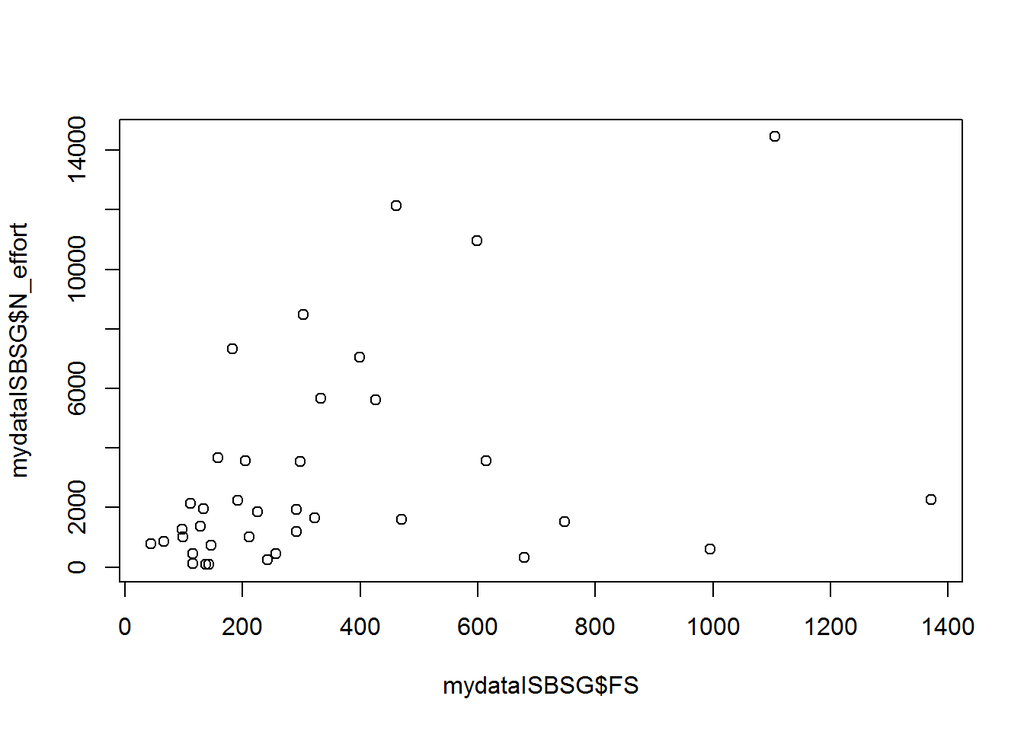

```r
plot(mydataISBSG$FS, mydataISBSG$N_effort)
```

## Flow of Control

Ifelse:

```r
library(foreign)
kc1 <- read.arff("../datasets/defectPred/D1/KC1.arff")
kc1$Defective <- ifelse(kc1$Defective == "Y", 1, 0)
head(kc1, 1)
```

```
##   LOC_BLANK BRANCH_COUNT LOC_CODE_AND_COMMENT LOC_COMMENTS
## 1         0            1                    0            0
##   CYCLOMATIC_COMPLEXITY DESIGN_COMPLEXITY ESSENTIAL_COMPLEXITY
## 1                     1                 1                    1
##   LOC_EXECUTABLE HALSTEAD_CONTENT HALSTEAD_DIFFICULTY HALSTEAD_EFFORT
## 1              3            11.58                2.67           82.35
##   HALSTEAD_ERROR_EST HALSTEAD_LENGTH HALSTEAD_LEVEL HALSTEAD_PROG_TIME
## 1               0.01              11           0.38               4.57
##   HALSTEAD_VOLUME NUM_OPERANDS NUM_OPERATORS NUM_UNIQUE_OPERANDS
## 1           30.88            4             7                   3
##   NUM_UNIQUE_OPERATORS LOC_TOTAL Defective
## 1                    4         5         0
```